# Updated XCMS workflow

The following code has been tested and run. Some extracts of code have been borrowed from the XCMS help documents and from Xiuxia Du’s coding session at the UAB short course 2018 - https://www.uab.edu/proteomics/metabolomics/workshop/2018/day4/use_XCMS3.R This is the updated workflow for xcms using the MSnBase objects. This workflow needs a little more starting code and familiarity with the R commands and general programming.

```r
rd
```

```
MSn experiment data ("OnDiskMSnExp")
Object size in memory: 2.69 Mb
- - - Spectra data - - -
 MS level(s): 1
 Number of spectra: 11000
 MSn retention times: 0:2 - 16:8 minutes
- - - Processing information - - -
Data loaded [Fri Mar  1 14:55:13 2019]
 MSnbase version: 2.8.3
- - - Meta data  - - -
phenoData
  rowNames: 1 2 ... 11 (11 total)
  varLabels: sample_name sample_group
  varMetadata: labelDescription
Loaded from:
  [1] URA3_control_H2O_1.mzML...  [11] VNG2094G_H2O_3.mzML
  Use 'fileNames(.)' to see all files.
protocolData: none
featureData
  featureNames: F01.S0001 F01.S0002 ... F11.S1000 (11000 total)
  fvarLabels: fileIdx spIdx ... spectrum (30 total)
  fvarMetadata: labelDescription
experimentData: use 'experimentData(object)'
```

We have now loaded the data into the new xcms3 object type. You can see the output info from the object by calling the object. You’ll also notice that the way the data is read is ‘onDisk’ as opposed to ‘inMemory’. ‘onDisk’ allows xcms to call up chunks of data at a time rather than the whole file loaded into memory.

Next we’ll load up some parameters for peak detection using the centWave peak detector algorithm. This setup will run on all CPU cores of system.

```r
iso.cfp<-CentWavePredIsoParam(peakwidth=c(2,30), prefilter=c(3,200), snthresh=3, verboseColumns=T)
# cfp<-CentWaveParam(peakwidth=peakwidth, ppm=ppm, prefilter=prefilter, snthresh=snthresh)
res<-findChromPeaks(rd, param=iso.cfp)
```

[output not shown]

```r
head(chromPeaks(res))
```

```
              mz    mzmin    mzmax     rt  rtmin  rtmax      into      intb      maxo sn egauss mu sigma  h   f dppm
CP00001 214.0525 214.0509 214.0576 11.054  5.255 16.852  1531.009  1243.829  359.4841  7     NA NA    NA NA  65   14
CP00002 146.9089 146.9083 146.9093 42.946 41.013 44.879  3758.519  3650.173 1042.1096  8     NA NA    NA NA 250    7
CP00003 183.9655 183.9622 183.9672 39.080 33.281 43.912  9953.804  9475.916 1828.9869 10     NA NA    NA NA 282   14
CP00004 160.9273 160.9261 160.9286 52.610 32.314 70.972 44833.411 44284.389 1864.1775 16     NA NA    NA NA 313    8
CP00005 163.9098 163.9091 163.9126  6.222  4.289  7.188  1679.340  1675.128  713.1488 97     NA NA    NA NA 323   22
CP00006 163.9097 163.9074 163.9124 55.509 30.382 65.172 13350.707 13312.803  693.1331 75     NA NA    NA NA 323    8
        scale scpos scmin scmax lmin lmax sample is_filled
CP00001     3    10     7    13    4   16      1         0
CP00002     1    43    42    44   41   45      1         0
CP00003     3    39    36    42   33   44      1         0
CP00004     9    53    44    62   32   72      1         0
CP00005     1     5     4     6    3    6      1         0
CP00006     9    56    47    65   30   66      1         0
```

Now we have a new object that has a new object called ‘res’ that is an XCMSnExp object type. Before the ‘rd’ object was a MSnBase object ‘OnDiskMSnExp’ type is is more for the raw data than the processed data of XCMS.

At this point we just have a peak list, a location of where each peak is located in each file. To get a group of peaks that are in the same m/z and RT we need to group the peaks into features. To do this we can run the PeakDensity algorithm.

```r
pdp <- PeakDensityParam(sampleGroups=(rd@phenoData@data$sample_group), binSize=0.05, minFraction = 0.5, bw = 20)
res <- groupChromPeaks(res, param = pdp)
```

```
Processing 55959 mz slices ... OK
```

What you’ll also notice is that each time we ask for a new algorithm we create an object for the parameters. This allows this object type to remember this call history that has happened to this ‘XCMSMSnExp’ object.

```r
head(chromPeaks(res)[order(chromPeaks(res)[,"maxo"], decreasing=T),])
```

```
              mz    mzmin    mzmax      rt   rtmin   rtmax     into     intb    maxo    sn egauss mu sigma  h     f dppm scale scpos scmin scmax lmin lmax sample is_filled
CP55413 132.0744 132.0743 132.0746 105.784  98.053 111.583 19055008 19042982 2431615  2391     NA NA    NA NA 25758    2     3   108   105   111   60   74     11         0
CP55416 132.0744 132.0743 132.0745 105.784 105.784 108.684  7453003  7449796 2431615  2391     NA NA    NA NA 25758    2     1   108   107   109   68   71     11         0
CP49940 132.0746 132.0745 132.0746 105.379 102.480 108.279 12221483 12219104 2422099  5657     NA NA    NA NA 25086    1     1   108   107   109   64   70     10         0
CP44349 132.0745 132.0744 132.0745 105.230 102.331 109.095 12619083 12613236 2290147  3071     NA NA    NA NA 25353    0     1   107   106   108   63   70      9         0
CP33669 132.0747 132.0746 132.0748 105.616 102.717 108.516 11080461 11079649 2240198 11525     NA NA    NA NA 25037    1     1   108   107   109   64   70      7         0
CP39011 132.0746 132.0744 132.0749 105.919  98.188 111.718 17033000 17022653 2179880  3325     NA NA    NA NA 24949    1     3   108   105   111   59   73      8         0
```

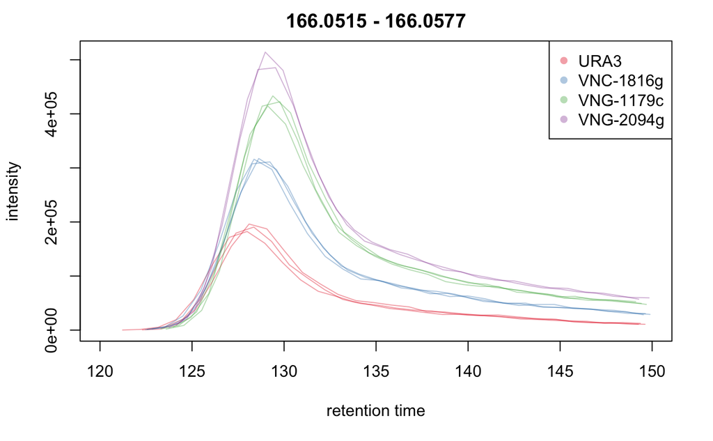

```r
mzr<-c(166.05, 166.06)
rtr<-c(2,2.5)*60 ## convert to seconds
group_number<-length(unique(pd[,"sample_group"]))
group_colors <- paste0(brewer.pal(group_number, "Set1")[1:group_number], "60")
names(group_colors) <- unique(pd[,"sample_group"])
chr_raw <- chromatogram(rd, mz = mzr, rt = rtr)
plot(chr_raw, col = group_colors[chr_raw$sample_group])
legend("topright", legend=names(group_colors),
       col=group_colors, cex=1, pch=16)
```

Above you can see an EIC of the peak that we were looking for. This data has been generated directly from the raw data itself.

Although this data looks fairly well aligned we will still go ahead and align the data. Below it’s worth playing with the parameters to see what effect they have on the alignment.

```r
bpis_adj_prior <- chromatogram(res, aggregationFun = "max") ## get the chromatograph prior to alignment
obiwarp_parameters <- ObiwarpParam(binSize=0.1)
res <- adjustRtime(res, param=obiwarp_parameters)
```

[output not shown]

```r
cat("Below are the adjusted retention times per samples\n")
```

```
Below are the adjusted retention times per samples
```

```r
head(adjustedRtime(res))
```

```
F01.S0001 F01.S0002 F01.S0003 F01.S0004 F01.S0005 F01.S0006
 2.020000  2.971199  3.923900  4.876132  5.829862  6.783114
```

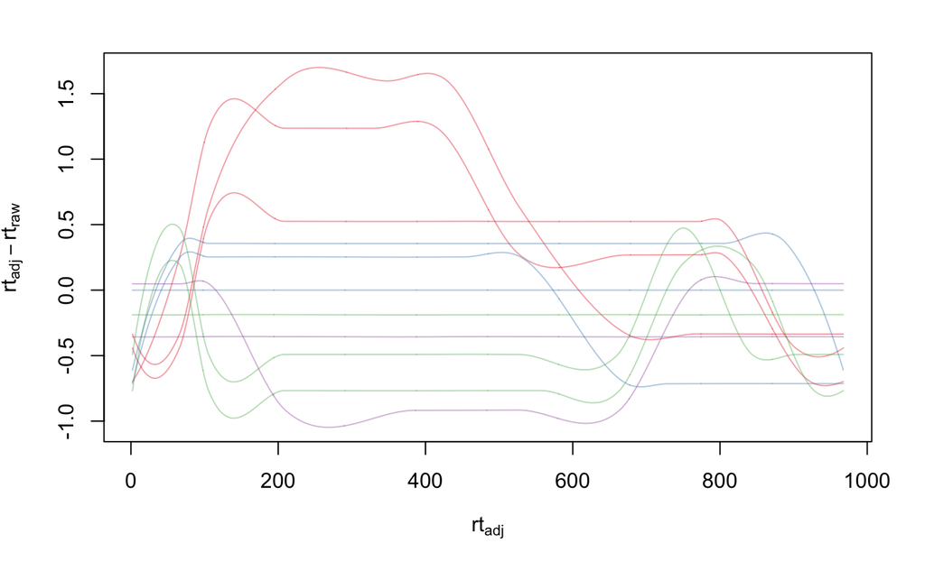

```r
plotAdjustedRtime(res,
                  col = group_colors[res$sample_group],
                  peakGroupsCol = "grey",
                  peakGroupsPch = 1)

bpis_adj <- chromatogram(res, aggregationFun = "max")
par(mfrow = c(2, 1))
```

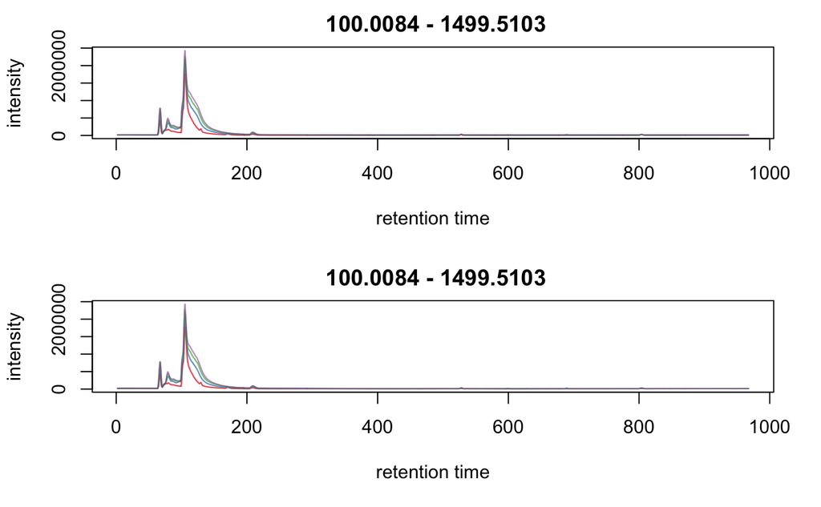

```r
plot(bpis_adj_prior, col = group_colors[bpis_adj_prior$sample_group])
plot(bpis_adj, col = group_colors[bpis_adj$sample_group])
```

```r
# ## Plot also the difference of adjusted to raw retention time.
# plotAdjustedRtime(res, col = group_colors[res$sample_group])
```

Above the images show the retention time drift. Between the two plots before and after there is probable not much difference. With other files this alignment can be much more pronounced.

```r
## Plot the raw data
pdp <- PeakDensityParam(sampleGroups=(rd@phenoData@data$sample_group), binSize=0.05, minFraction = 0.5, bw = max(adjustedRtime(res)))
res <- groupChromPeaks(res, param = pdp)
```

```
Processing 55959 mz slices ... OK
```

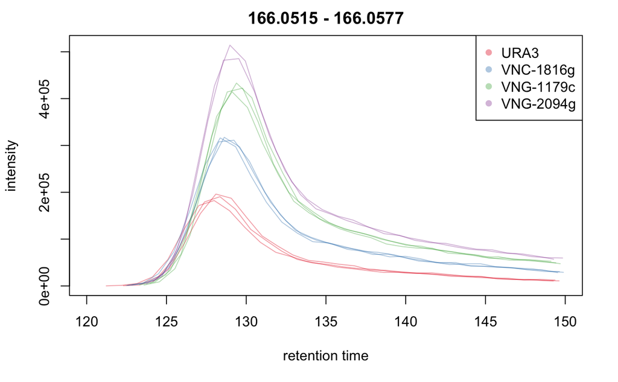

```r
chr_raw <- chromatogram(rd, mz = mzr, rt = rtr)
plot(chr_raw, col = group_colors[chr_raw$sample_group])
legend("topright", legend=names(group_colors),
       col=group_colors, cex=1, pch=16)
```

```r
res <- fillChromPeaks(res)
```

[output not shown]

```r
dat<-cbind(featureDefinitions(res), featureValues(res, value = "into"))
```

However, quickly we can do a few plots to have a look at the data and look at doing some stats

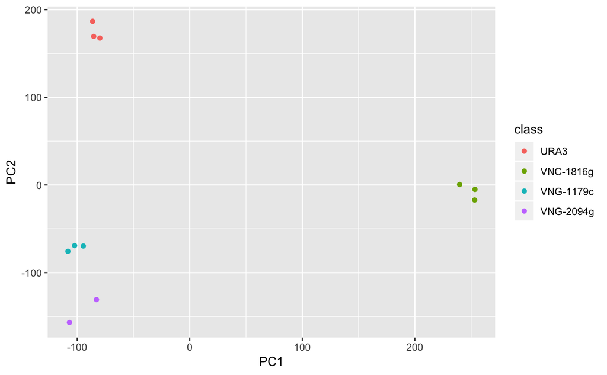

```r
require(pcaMethods)
require(ggplot2)
uvScale<-function(vals){
    temp.sd<-apply(vals, 1, sd, na.rm=T)
    temp.uv<-vals/temp.sd
    return(temp.uv)
} ## a small function to do UV scaling on all the data
logTrans<-function(vals){
    vals.log<-log10(abs(vals+1.0E-16))
} ## very small function to do log transformations
val<-featureValues(res, value = "into")
val[which(is.na(val))]<-0
valDiff<-logTrans(uvScale( t(val) ))
pca.results<-pcaMethods::pca(valDiff, nPcs=3, center=TRUE, scale="none")
sc<-data.frame(pca.results@scores, class=rd@phenoData@data$sample_group)
gg<- ggplot(sc, aes(PC1, PC2, colour=class)) +
                scale_size_area() + geom_point()
print(gg)
```